# Tugas-Pertemuan-3

Zanira Husna G1401231097

# Impor Data

```r
data <- read.csv("C:\\Users\\ZANIRA\\Downloads\\NewDelhi_Air_quality.csv")
str(data)
```

```
## 'data.frame':    72 obs. of  12 variables:
##  $ X              : int  0 1 2 3 4 5 6 7 8 9 ...
##  $ AQI            : num  30.2 28.2 26.6 25 26 26 26 24 23 24 ...
##  $ CO             : num  199 198 199 202 205 ...
##  $ datetime       : chr  "2022-10-21:18" "2022-10-21:19" "2022-10-21:20" "2022-10-21:21" ...
##  $ no2            : num  0.0469 0.0465 0.0469 0.0482 0.0489 ...
##  $ o3             : num  55.8 54.9 54.6 55.1 55.8 ...
##  $ pm10           : num  10.5 10.7 11.2 11.1 10.4 ...
##  $ pm25           : num  5.64 4.62 3.52 2.23 1.98 ...
##  $ so2            : num  0.387 0.41 0.402 0.376 0.339 ...
##  $ timestamp_local: chr  "2022-10-21T23:00:00" "2022-10-22T00:00:00" "2022-10-22T01:00:00" "2022-10-22T02:00:00" ...
##  $ timestamp_utc  : chr  "2022-10-21T18:00:00" "2022-10-21T19:00:00" "2022-10-21T20:00:00" "2022-10-21T21:00:00" ...
##  $ ts             : int  1666375200 1666378800 1666382400 1666386000 1666389600 1666393200 1666396800 1666400400 1666404000 1666407600 ...
```

```r
data
```

```
##     X  AQI       CO      datetime        no2       o3      pm10     pm25
## 1   0 30.2 198.6027 2022-10-21:18 0.04685717 55.78995 10.486722 5.637410
## 2   1 28.2 197.6013 2022-10-21:19 0.04645554 54.93164 10.719325 4.618169
## 3   2 26.6 198.6027 2022-10-21:20 0.04685717 54.64554 11.155578 3.520902
## 4   3 25.0 201.9405 2022-10-21:21 0.04819594 55.07469 11.116206 2.225919
## 5   4 26.0 205.2784 2022-10-21:22 0.04886533 55.78995 10.405250 1.979471
## 6   5 26.0 208.6163 2022-10-21:23 0.05020411 56.50520  9.402518 1.792677
## 7   6 26.0 208.6163 2022-10-22:00 0.05020411 55.78995  8.482822 1.752237
## 8   7 24.0 205.2784 2022-10-22:01 0.05020411 52.92892  7.586667 1.858459
## 9   8 23.0 200.2716 2022-10-22:02 0.04685717 50.06790  7.636587 2.208076
## 10  9 24.0 196.9338 2022-10-22:03 0.04417961 51.49841  8.487648 2.476681
## 11 10 25.0 198.6027 2022-10-22:04 0.04284084 53.64418  9.357371 2.585729
## 12 11 26.0 200.2716 2022-10-22:05 0.04049798 55.78995 10.338728 2.390081
## 13 12 27.0 203.6095 2022-10-22:06 0.04016329 59.36623 10.523314 2.086022
## 14 13 29.0 205.2784 2022-10-22:07 0.03882451 62.22725 10.635970 1.937047
```

[output cut: 131 more lines]

# Pembagian Data

```r
subset_data <- data[, c("AQI", "pm25")]
colnames(subset_data) <- c("Y", "X")

str(subset_data)
```

```
## 'data.frame':    72 obs. of  2 variables:
##  $ Y: num  30.2 28.2 26.6 25 26 26 26 24 23 24 ...
##  $ X: num  5.64 4.62 3.52 2.23 1.98 ...
```

```r
colSums(is.na(subset_data))
```

```
## Y X
## 0 0
```

```r
#SPLIT DATA
n <- nrow(subset_data)

# tentukan batas 80%
n_train <- floor(0.8 * n)

# bagi data
train <- subset_data[1:n_train, ]
test  <- subset_data[(n_train+1):n, ]
```

```r
nrow(test)
```

```
## [1] 15
```

```r
#data time series
train.ts<-ts(train)
test.ts<-ts(test)
data.ts<-ts(subset_data)
```

# Pemodelan Data

## Model Koyck

Model Koyck didasarkan pada asumsi bahwa semakin jauh jarak lag peubah independen dari periode sekarang maka semakin kecil pengaruh peubah lag terhadap peubah dependen.

### Pemodelan

```r
#MODEL KOYCK
model.koyck <- koyckDlm(x = train$X, y = train$Y)
summary(model.koyck)
```

```
##
## Call:
## "Y ~ (Intercept) + Y.1 + X.t"
##
## Residuals:
##      Min       1Q   Median       3Q      Max
## -2.19768 -0.57669 -0.03615  0.58158  2.18318
##
## Coefficients:
##             Estimate Std. Error t value Pr(>|t|)
## (Intercept)  4.54910    1.77579   2.562   0.0133 *
## Y.1          0.87326    0.05731  15.237   <2e-16 ***
## X.t         -0.56825    0.27658  -2.055   0.0449 *
## ---
## Signif. codes:  0 '***' 0.001 '**' 0.01 '*' 0.05 '.' 0.1 ' ' 1
##
## Residual standard error: 0.8986 on 53 degrees of freedom
## Multiple R-Squared: 0.8303,  Adjusted R-squared: 0.8239
## Wald test: 129.9 on 2 and 53 DF,  p-value: < 2.2e-16
##
## Diagnostic tests:
## NULL
##
##                             alpha       beta      phi
## Geometric coefficients:  35.89204 -0.5682546 0.873256
```

```r
AIC(model.koyck)
```

```
## [1] 151.8615
```

```r
BIC(model.koyck)
```

```
## [1] 159.9629
```

Dari hasil tersebut, didapat bahwa intercept, peubah $y_{t-1}$ dan $x_{t}$ memiliki nilai $P-Value<0.05$. Hal ini menunjukkan bahwa intercept, peubah $y_{t-1}$ dan $x_{t}$ berpengaruh signifikan terhadap $y$. Adapun model keseluruhannya adalah sebagai berikut

$$\hat{Y_t}=4.54910-0.56825X_t+0.87326Y_{t-1}$$

### Peramalan dan Akurasi

Berikut adalah hasil peramalan y untuk 15 periode kedepan menggunakan model koyck

```r
fore.koyck <- forecast(model = model.koyck, x=test$X, h=15)
fore.koyck
```

```
## $forecasts
##  [1] 24.95927 24.78189 24.49412 24.19650 23.90670 23.66965 23.52745 23.47683
##  [9] 23.47525 23.49718 23.52224 23.54830 23.55405 23.53805 23.54349
##
## $call
## forecast.koyckDlm(model = model.koyck, x = test$X, h = 15)
##
## attr(,"class")
## [1] "forecast.koyckDlm" "dLagM"
```

```r
mape.koyck <- MAPE(fore.koyck$forecasts, test$Y)
mape.koyck #data test
```

```
## [1] 0.1394956
```

```r
#akurasi data training
GoF(model.koyck)
```

```
##              n       MAE         MPE       MAPE      sMAPE     MASE       MSE
## model.koyck 56 0.6708393 -0.00101664 0.02495405 0.02490925 1.048186 0.7642032
##                  MRAE   GMRAE
## model.koyck 836328982 13944.2
```

Dari nilai MAPE sebesar 0.02495405 < 0.1 dapat disimpulkan model koyck merupakan forecasting yang baik dan dapat digunakan secara efektif untuk meramalkan nilai variabel dependen pada periode mendatang.

## Regression with Distributed Lag

```r
model.dlm <- dlm(x = train$X,y = train$Y , q = 1)
summary(model.dlm)
```

```
##
## Call:
## lm(formula = model.formula, data = design)
##
## Residuals:
##     Min      1Q  Median      3Q     Max
## -4.8774 -1.3623 -0.4143  0.9707  4.3977
##
## Coefficients:
##             Estimate Std. Error t value Pr(>|t|)
## (Intercept)   31.354      1.426  21.986  < 2e-16 ***
## x.t           -4.509      1.644  -2.744  0.00828 **
## x.1            2.431      1.161   2.095  0.04098 *
## ---
## Signif. codes:  0 '***' 0.001 '**' 0.01 '*' 0.05 '.' 0.1 ' ' 1
##
## Residual standard error: 2.011 on 53 degrees of freedom
## Multiple R-squared:  0.1505, Adjusted R-squared:  0.1184
## F-statistic: 4.694 on 2 and 53 DF,  p-value: 0.01328
##
## AIC and BIC values for the model:
##        AIC      BIC
## 1 242.0647 250.1661
```

```r
AIC(model.dlm)
```

```
## [1] 242.0647
```

```r
BIC(model.dlm)
```

```
## [1] 250.1661
```

Dari hasil diatas, didapat bahwa $P-value$ dari intercept, $x_{t}$ dan, $x_{t-1}<0.05$. Hal ini menunjukkan bahwa intercept, $x_{t}$, dan $x_{t-1}$ berpengaruh signifikan terhadap $y$. Adapun model keseluruhan yang terbentuk adalah sebagai berikut

$$\hat{Y_t}=31.354-4.509X_t+2.431X_{t-1}$$

### Peramalan dan Akurasi

Berikut merupakan hasil peramalan $y$ untuk 15 periode kedepan

```r
fore.dlm <- forecast(model = model.dlm, x=test$X, h=15)
fore.dlm
```

```
## $forecasts
##  [1] 25.49806 25.03159 24.58408 24.78494 24.74592 25.00094 25.44668 25.75313
##  [9] 25.77659 25.77926 25.72629 25.73426 25.58137 25.48741 25.73130
##
## $call
## forecast.dlm(model = model.dlm, x = test$X, h = 15)
##
## attr(,"class")
## [1] "forecast.dlm" "dLagM"
```

```r
mape.dlm <- MAPE(fore.dlm$forecasts, test$Y)
mape.dlm
```

```
## [1] 0.1748723
```

```r
#akurasi data training
GoF(model.dlm)
```

```
##            n     MAE          MPE       MAPE      sMAPE     MASE      MSE
## model.dlm 56 1.52298 -0.005047837 0.05567185 0.05568748 2.379656 3.826113
##                 MRAE    GMRAE
## model.dlm 6185455636 31042.32
```

Dari nilai MAPE sebesar 0.05567185 < 0.1 dapat disimpulkan model merupakan forecasting yang baik dan dapat digunakan secara efektif untuk meramalkan nilai variabel dependen pada periode mendatang.

### *Lag* Optimum

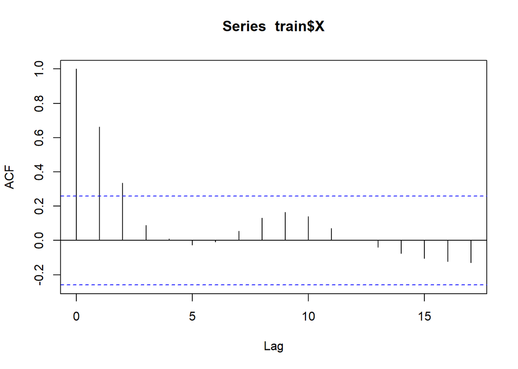

```r
acf(train$X)
```

```r
#penentuan lag optimum
finiteDLMauto(
  formula = Y ~ X,
  data = train,
  q.min = 1,
  q.max = 10,
  model.type = "dlm",
  error.type = "AIC",
  trace = TRUE
)
```

```
##    q - k    MASE      AIC      BIC    GMRAE    MBRAE R.Adj.Sq    Ljung-Box
## 10    10 1.79180 181.4052 205.4571 69409.72  1.83368  0.50588 4.814509e-08
## 9      9 1.95552 192.2161 214.6706 59217.09 -0.65007  0.43896 3.162063e-08
## 8      8 2.01622 196.5406 217.3506 51171.73  0.67925  0.46088 2.929916e-10
## 7      7 1.96730 197.4880 216.6082 40347.66  0.63118  0.49602 6.697151e-10
## 6      6 1.83971 198.5178 215.9042 28047.21  0.57217  0.50809 5.471995e-10
## 5      5 1.86028 201.4950 217.1050 31164.02 -0.91742  0.50052 9.449556e-10
## 4      4 1.97485 207.2937 221.0857 40854.21  0.73804  0.46486 3.806880e-09
## 3      3 2.24020 217.2830 229.2169 49384.27  0.80165  0.38957 1.527662e-09
## 2      2 2.28777 229.4667 239.5034 38705.59  1.30509  0.26580 9.176708e-07
## 1      1 2.37966 242.0647 250.1661 31042.32  0.66469  0.11843 2.695019e-09
```

Berdasarkan output tersebut, lag optimum didapatkan ketika lag=10. Selanjutnya dilakukan pemodelan untuk lag=10

```r
#model dlm dengan lag optimum
model.dlm2 <- dlm(x = train$X,y = train$Y , q = 10)
summary(model.dlm2)
```

```
##
## Call:
## lm(formula = model.formula, data = design)
##
## Residuals:
##      Min       1Q   Median       3Q      Max
## -2.71041 -0.83916  0.09733  0.83799  2.91674
##
## Coefficients:
##             Estimate Std. Error t value Pr(>|t|)
## (Intercept)   40.971      2.293  17.869  < 2e-16 ***
## x.t          -20.622      6.211  -3.320  0.00211 **
## x.1           13.567     13.579   0.999  0.32458
## x.2            5.848     16.535   0.354  0.72570
## x.3           -1.330     15.861  -0.084  0.93363
## x.4           -2.878     15.189  -0.190  0.85079
## x.5           -4.771     14.732  -0.324  0.74798
## x.6           16.900     12.053   1.402  0.16968
## x.7          -18.277      6.733  -2.714  0.01024 *
## x.8            3.422      4.514   0.758  0.45342
## x.9            6.711      4.327   1.551  0.12987
## x.10          -5.245      2.067  -2.537  0.01579 *
## ---
## Signif. codes:  0 '***' 0.001 '**' 0.01 '*' 0.05 '.' 0.1 ' ' 1
##
## Residual standard error: 1.465 on 35 degrees of freedom
## Multiple R-squared:  0.624,  Adjusted R-squared:  0.5059
## F-statistic: 5.281 on 11 and 35 DF,  p-value: 7.336e-05
##
## AIC and BIC values for the model:
##        AIC      BIC
## 1 181.4052 205.4571
```

```r
AIC(model.dlm2)
```

```
## [1] 181.4052
```

```r
BIC(model.dlm2)
```

```
## [1] 205.4571
```

Dari hasil tersebut terdapat beberapa peubah yang berpengaruh signifikan terhadap taraf nyata 5% yaitu Intercept, $x_t$ , $x_{t-7}$ , $x_{t-10}$. Adapun keseluruhan model yang terbentuk adalah

$$\hat{Y_t}=40.971-20.622X_t-18.277X_{t-7}-5.245X_{t-10}$$

Adapun hasil peramalan 15 periode kedepan menggunakan model tersebut adalah sebagai berikut

```r
#peramalan dan akurasi
fore.dlm2 <- forecast(model = model.dlm2, x=test$X, h=15)

#akurasi data test
mape.dlm2 <- MAPE(fore.dlm2$forecasts, test$Y)
mape.dlm2
```

```
## [1] 0.144226
```

```r
#akurasi data training
GoF(model.dlm2)
```

```
##             n      MAE          MPE       MAPE      sMAPE     MASE      MSE
## model.dlm2 47 1.012758 -0.002026638 0.03660523 0.03650655 1.791802 1.597781
##                  MRAE    GMRAE
## model.dlm2 6456109988 69409.72
```

Dari nilai MAPE sebesar 0.03660523 < 0.1 dapat disimpulkan model merupakan forecasting yang baik dan dapat digunakan secara efektif untuk meramalkan nilai variabel dependen pada periode mendatang.

## Model Autoregressive

### Pemodelan

```r
model.ardl <- ardlDlm(formula = Y ~ X,
                         data = train,p = 1 , q = 1)
summary(model.ardl)
```

```
##
## Time series regression with "ts" data:
## Start = 2, End = 57
##
## Call:
## dynlm(formula = as.formula(model.text), data = data)
##
## Residuals:
##      Min       1Q   Median       3Q      Max
## -2.19437 -0.53377 -0.07398  0.53245  2.18819
##
## Coefficients:
##             Estimate Std. Error t value Pr(>|t|)
## (Intercept)  3.84416    2.00316   1.919   0.0605 .
## X.t         -0.09036    0.79948  -0.113   0.9104
## X.1         -0.31343    0.55520  -0.565   0.5748
## Y.1          0.88721    0.06120  14.496   <2e-16 ***
## ---
## Signif. codes:  0 '***' 0.001 '**' 0.01 '*' 0.05 '.' 0.1 ' ' 1
##
## Residual standard error: 0.9041 on 52 degrees of freedom
## Multiple R-squared:  0.8315, Adjusted R-squared:  0.8218
## F-statistic: 85.52 on 3 and 52 DF,  p-value: < 2.2e-16
```

```r
AIC(model.ardl)
```

```
## [1] 153.478
```

```r
BIC(model.ardl)
```

```
## [1] 163.6048
```

Hasil di atas menunjukkan bahwa peubah, hasil uji t menunjukkan nilai-p pada peubah $y_{t-1}<0.05$ Hal ini menunjukkan bahwa peubah $y_{t-1}$ berpengaruh signifikan terhadap $y_t$. Model keseluruhannya adalah sebagai berikut:

$$\hat{Y}=3.84416 +0.88721Y_{t-1}$$

### Peramalan dan Akurasi

```r
fore.ardl <- forecast(model = model.ardl, x=test$X, h=15)
fore.ardl
```

```
## $forecasts
##  [1] 25.09935 25.07999 24.96347 24.77944 24.58586 24.40017 24.25456 24.17282
##  [9] 24.14765 24.15254 24.17067 24.19068 24.20803 24.21070 24.20457
##
## $call
## forecast.ardlDlm(model = model.ardl, x = test$X, h = 15)
##
## attr(,"class")
## [1] "forecast.ardlDlm" "dLagM"
```

Data di atas merupakan hasil peramalan untuk 15 periode ke depan menggunakan Model Autoregressive dengan $p=1$ dan $q=1$.

```r
mape.ardl <- MAPE(fore.ardl$forecasts, test$Y)
mape.ardl
```

```
## [1] 0.1543609
```

```r
#akurasi data training
GoF(model.ardl)
```

```
##             n       MAE          MPE       MAPE      sMAPE     MASE       MSE
## model.ardl 56 0.6649318 -0.001022605 0.02471495 0.02467317 1.038956 0.7589879
##                 MRAE    GMRAE
## model.ardl 764716569 13547.56
```

### *Lag* Optimum

```r
#penentuan lag optimum
model.ardl.opt <- ardlBoundOrders(data = data.frame(subset_data), ic = "AIC",
                                  formula = Y ~ X )
model.ardl.opt
```

```
## $p
##    X
## 1 15
##
## $q
## [1] 5
##
## $Stat.table
##           q = 1    q = 2    q = 3    q = 4    q = 5    q = 6    q = 7    q = 8
## p = 1  175.6638 173.4300 169.4588 153.4179 153.0743 151.1206 144.9328 145.9197
## p = 2  173.3465 173.4835 170.1115 155.4157 151.3281 145.4609 142.2415 143.1635
## p = 3  170.6630 170.6630 172.0632 157.3058 152.4389 143.5828 142.5900 143.5356
## p = 4  153.4709 155.4432 155.4432 154.6363 149.6701 143.3774 144.5209 145.4322
## p = 5  147.2972 149.2970 151.2887 151.2887 151.4674 144.9280 145.9614 145.3283
## p = 6  137.8965 139.8447 141.7903 143.1942 143.1942 144.0834 144.8809 142.7234
## p = 7  148.4421 148.5238 148.1127 146.0607 143.4367 143.4367 145.4223 143.8002
## p = 8  140.5719 141.0397 141.8280 141.9797 140.7112 141.2079 141.2079 143.0516
## p = 9  146.2825 142.3373 141.1879 140.7472 139.5962 141.0394 142.4976 142.4976
## p = 10 150.4402 144.7181 142.6828 141.9912 139.6346 141.4725 142.6619 144.6327
## p = 11 148.7483 142.8007 139.5594 139.2561 130.4437 132.4436 133.3735 135.3613
## p = 12 145.6517 138.8176 135.5105 134.9701 127.4923 128.8063 129.3052 131.2456
## p = 13 147.6700 138.8567 136.2592 137.1445 131.6268 133.5459 134.9739 136.9144
## p = 14 147.9332 139.5295 135.8578 136.4160 132.8957 134.8866 136.5186 138.3974
## p = 15 145.2797 135.1519 132.2959 133.0945 124.7089 126.7065 128.6573 130.6374
##           q = 9   q = 10   q = 11   q = 12   q = 13   q = 14   q = 15
## p = 1  146.1822 145.1524 141.7981 141.7971 136.3636 134.9485 133.7805
## p = 2  142.4039 143.1442 140.0579 137.3658 134.7689 135.3957 134.3190
## p = 3  143.3060 143.9315 140.8152 138.0758 136.6450 137.0960 136.2864
## p = 4  145.1476 145.8591 142.5665 140.0567 138.5906 139.0671 138.2374
## p = 5  143.3443 143.3033 138.7263 138.5509 138.2344 138.2887 136.5913
## p = 6  143.7239 144.6324 140.0156 139.9542 140.1107 140.2790 138.5596
## p = 7  144.9764 145.8288 139.9750 138.0631 137.1651 135.0759 135.5428
## p = 8  144.3615 144.4638 140.6567 133.8244 132.9980 132.6996 132.4038
## p = 9  144.3583 144.6840 138.0590 135.8007 134.6425 134.2178 134.2594
## p = 10 144.6327 146.5713 139.5722 137.7714 136.3764 136.1647 136.2013
## p = 11 136.1546 136.1546 136.7182 135.6091 133.8928 133.6618 134.8254
## p = 12 132.3942 134.3067 134.3067 135.1873 133.4581 134.0468 133.2658
## p = 13 136.7088 137.5455 136.5324 136.5324 135.2556 135.7380 135.2432
## p = 14 137.0029 136.2761 133.5555 135.2334 135.2334 137.1634 136.2598
## p = 15 132.0212 132.1933 129.1212 131.1030 131.3276 131.3276 133.0357
##
## $min.Stat
## [1] 124.7089
```

```r
min_p=c()
for(i in 1:6){
  min_p[i]=min(model.ardl.opt$Stat.table[[i]])
}
q_opt=which(min_p==min(min_p, na.rm = TRUE))
p_opt=which(model.ardl.opt$Stat.table[[q_opt]] ==
              min(model.ardl.opt$Stat.table[[q_opt]], na.rm = TRUE))
data.frame("q_optimum" = q_opt, "p_optimum" = p_opt,
           "AIC"=model.ardl.opt$min.Stat)
```

```
##   q_optimum p_optimum      AIC
## 1         5        15 124.7089
```

Dari tabel di atas, dapat terlihat bahwa nilai AIC terendah didapat ketika $p=15$ dan $q=5$, yaitu sebesar `124.7089`. Artinya, model autoregressive optimum didapat ketika $p=15$ dan $q=5$.

## Pemodelan DLM & ARDL dengan Library `dynlm`

```r
#sama dengan model dlm q=1
cons_lm1 <- dynlm(Y ~ X+L(X),data = train.ts)

#sama dengan model ardl p=1 q=0
cons_lm2 <- dynlm(Y ~ X+L(Y),data = train.ts)

#sama dengan ardl p=15 q=5
cons_lm3 <- dynlm(Y ~ X + L(X, 1:15) + L(Y, 1:5), data = train.ts)

#sama dengan dlm p=2
cons_lm4 <- dynlm(Y ~ X+L(X)+L(X,2),data = train.ts)
```

### Ringkasan Model

Berikut adalah ringkasan hasil estimasi dari masing-masing model:

```r
summary(cons_lm1)
```

```
##
## Time series regression with "ts" data:
## Start = 2, End = 57
##
## Call:
## dynlm(formula = Y ~ X + L(X), data = train.ts)
##
## Residuals:
##     Min      1Q  Median      3Q     Max
## -4.8774 -1.3623 -0.4143  0.9707  4.3977
##
## Coefficients:
##             Estimate Std. Error t value Pr(>|t|)
## (Intercept)   31.354      1.426  21.986  < 2e-16 ***
## X             -4.509      1.644  -2.744  0.00828 **
## L(X)           2.431      1.161   2.095  0.04098 *
## ---
## Signif. codes:  0 '***' 0.001 '**' 0.01 '*' 0.05 '.' 0.1 ' ' 1
##
## Residual standard error: 2.011 on 53 degrees of freedom
## Multiple R-squared:  0.1505, Adjusted R-squared:  0.1184
## F-statistic: 4.694 on 2 and 53 DF,  p-value: 0.01328
```

```r
summary(cons_lm2)
```

```
##
## Time series regression with "ts" data:
## Start = 2, End = 57
##
## Call:
## dynlm(formula = Y ~ X + L(Y), data = train.ts)
##
## Residuals:
##      Min       1Q   Median       3Q      Max
## -2.18297 -0.59646 -0.04547  0.58794  2.19134
##
## Coefficients:
##             Estimate Std. Error t value Pr(>|t|)
## (Intercept)  4.38211    1.75064   2.503   0.0154 *
## X           -0.51661    0.26111  -1.979   0.0531 .
## L(Y)         0.87542    0.05716  15.315   <2e-16 ***
## ---
## Signif. codes:  0 '***' 0.001 '**' 0.01 '*' 0.05 '.' 0.1 ' ' 1
##
## Residual standard error: 0.8983 on 53 degrees of freedom
## Multiple R-squared:  0.8304, Adjusted R-squared:  0.8241
## F-statistic: 129.8 on 2 and 53 DF,  p-value: < 2.2e-16
```

```r
summary(cons_lm3)
```

```
##
## Time series regression with "ts" data:
## Start = 16, End = 57
##
## Call:
## dynlm(formula = Y ~ X + L(X, 1:15) + L(Y, 1:5), data = train.ts)
##
## Residuals:
##      Min       1Q   Median       3Q      Max
## -0.82795 -0.21807 -0.06184  0.19832  0.95292
##
## Coefficients:
##              Estimate Std. Error t value Pr(>|t|)
## (Intercept)   6.39323    8.42066   0.759   0.4566
## X            -9.79936    3.63098  -2.699   0.0138 *
## L(X, 1:15)1  12.55109    7.60359   1.651   0.1144
## L(X, 1:15)2   2.80197    9.55656   0.293   0.7724
## L(X, 1:15)3  -0.03494   10.20593  -0.003   0.9973
## L(X, 1:15)4  -8.75652   10.57855  -0.828   0.4176
## L(X, 1:15)5   7.05101   10.68081   0.660   0.5167
## L(X, 1:15)6  -4.23104   10.02790  -0.422   0.6776
## L(X, 1:15)7  -2.27689    9.98750  -0.228   0.8220
## L(X, 1:15)8  -0.02309    9.52703  -0.002   0.9981
## L(X, 1:15)9   1.79410    8.66257   0.207   0.8380
## L(X, 1:15)10  0.55336    7.76096   0.071   0.9439
## L(X, 1:15)11 -1.03757    6.05781  -0.171   0.8657
## L(X, 1:15)12  1.60399    3.91378   0.410   0.6863
## L(X, 1:15)13 -0.35479    2.86667  -0.124   0.9027
## L(X, 1:15)14 -1.91046    2.85174  -0.670   0.5106
## L(X, 1:15)15  1.61309    1.52639   1.057   0.3032
## L(Y, 1:5)1    0.57609    0.23251   2.478   0.0223 *
## L(Y, 1:5)2    0.58447    0.26711   2.188   0.0407 *
## L(Y, 1:5)3    0.18559    0.26449   0.702   0.4910
## L(Y, 1:5)4   -0.21285    0.26613  -0.800   0.4332
## L(Y, 1:5)5   -0.33394    0.21453  -1.557   0.1353
## ---
## Signif. codes:  0 '***' 0.001 '**' 0.01 '*' 0.05 '.' 0.1 ' ' 1
##
## Residual standard error: 0.608 on 20 degrees of freedom
## Multiple R-squared:  0.9604, Adjusted R-squared:  0.9187
## F-statistic: 23.07 on 21 and 20 DF,  p-value: 8.9e-10
```

```r
summary(cons_lm4)
```

```
##
## Time series regression with "ts" data:
## Start = 3, End = 57
##
## Call:
## dynlm(formula = Y ~ X + L(X) + L(X, 2), data = train.ts)
##
## Residuals:
##     Min      1Q  Median      3Q     Max
## -4.3400 -1.1824 -0.0772  1.0259  4.0422
##
## Coefficients:
##             Estimate Std. Error t value Pr(>|t|)
## (Intercept)   35.139      1.715  20.485  < 2e-16 ***
## X             -7.940      2.282  -3.480  0.00104 **
## L(X)           6.040      3.265   1.850  0.07012 .
## L(X, 2)       -2.033      1.571  -1.294  0.20149
## ---
## Signif. codes:  0 '***' 0.001 '**' 0.01 '*' 0.05 '.' 0.1 ' ' 1
##
## Residual standard error: 1.848 on 51 degrees of freedom
## Multiple R-squared:  0.3066, Adjusted R-squared:  0.2658
## F-statistic: 7.516 on 3 and 51 DF,  p-value: 0.0002938
```

### SSE

Selain ringkasan hasil, kita juga bisa menghitung nilai SSE dari masing-masing model.

```r
deviance(cons_lm1)
```

```
## [1] 214.2624
```

```r
deviance(cons_lm2)
```

```
## [1] 42.76382
```

```r
deviance(cons_lm3)
```

```
## [1] 7.392728
```

```r
deviance(cons_lm4)
```

```
## [1] 174.1227
```

Semakin kecil nilai SSE, berarti model lebih baik dalam menyesuaikan data (karena error lebih kecil). Model terbaik merupakan Model ke-3 dengan SSE 7.392728

#### Uji Autokorelasi Residual

```r
#durbin watson
dwtest(cons_lm1)
```

```
##
##  Durbin-Watson test
##
## data:  cons_lm1
## DW = 0.36907, p-value = 3.414e-16
## alternative hypothesis: true autocorrelation is greater than 0
```

```r
dwtest(cons_lm2)
```

```
##
##  Durbin-Watson test
##
## data:  cons_lm2
## DW = 1.1212, p-value = 0.0001009
## alternative hypothesis: true autocorrelation is greater than 0
```

```r
dwtest(cons_lm3)
```

```
##
##  Durbin-Watson test
##
## data:  cons_lm3
## DW = 2.3211, p-value = 0.5055
## alternative hypothesis: true autocorrelation is greater than 0
```

```r
dwtest(cons_lm4)
```

```
##
##  Durbin-Watson test
##
## data:  cons_lm4
## DW = 0.6555, p-value = 1.065e-09
## alternative hypothesis: true autocorrelation is greater than 0
```

#### Uji Heterogenitas

```r
bptest(cons_lm1)
```

```
##
##  studentized Breusch-Pagan test
##
## data:  cons_lm1
## BP = 8.3784, df = 2, p-value = 0.01516
```

```r
bptest(cons_lm2)
```

```
##
##  studentized Breusch-Pagan test
##
## data:  cons_lm2
## BP = 0.52283, df = 2, p-value = 0.77
```

```r
bptest(cons_lm3)
```

```
##
##  studentized Breusch-Pagan test
##
## data:  cons_lm3
## BP = 23.568, df = 21, p-value = 0.3145
```

```r
bptest(cons_lm4)
```

```
##
##  studentized Breusch-Pagan test
##
## data:  cons_lm4
## BP = 13.272, df = 3, p-value = 0.004084
```

#### Uji Normalitas

H0: Residual berdistribusi normal.

H1: Residual tidak berdistribusi normal.

```r
shapiro.test(residuals(cons_lm1))
```

```
##
##  Shapiro-Wilk normality test
##
## data:  residuals(cons_lm1)
## W = 0.96118, p-value = 0.06876
```

```r
shapiro.test(residuals(cons_lm2))
```

```
##
##  Shapiro-Wilk normality test
##
## data:  residuals(cons_lm2)
## W = 0.9849, p-value = 0.7062
```

```r
shapiro.test(residuals(cons_lm3))
```

```
##
##  Shapiro-Wilk normality test
##
## data:  residuals(cons_lm3)
## W = 0.97586, p-value = 0.5077
```

```r
shapiro.test(residuals(cons_lm4))
```

```
##
##  Shapiro-Wilk normality test
##
## data:  residuals(cons_lm4)
## W = 0.97474, p-value = 0.2976
```

## Perbandingan Model

Membuat tabel ringkas akurasi model berdasarkan nilai MAPE (Mean Absolute Percentage Error).

```r
akurasi <- matrix(c(mape.koyck, mape.dlm, mape.dlm2, mape.ardl))
row.names(akurasi)<- c("Koyck","DLM 1","DLM 2","Autoregressive")
colnames(akurasi) <- c("MAPE")
akurasi
```

```
##                     MAPE
## Koyck          0.1394956
## DLM 1          0.1748723
## DLM 2          0.1442260
## Autoregressive 0.1543609
```

Berdasarkan nilai MAPE, model paling optimum didapat pada Model Koyck karena memiliki nilai MAPE yang terkecil yaitu 0.1394956.

### Plot

Untuk membandingkan hasil peramalan dari berbagai model (Koyck, DLM 1, DLM 2, dan ARDL) dengan data aktual, dibuat grafik garis. Visualisasi ini membantu melihat seberapa dekat hasil ramalan tiap model dengan nilai aktual.

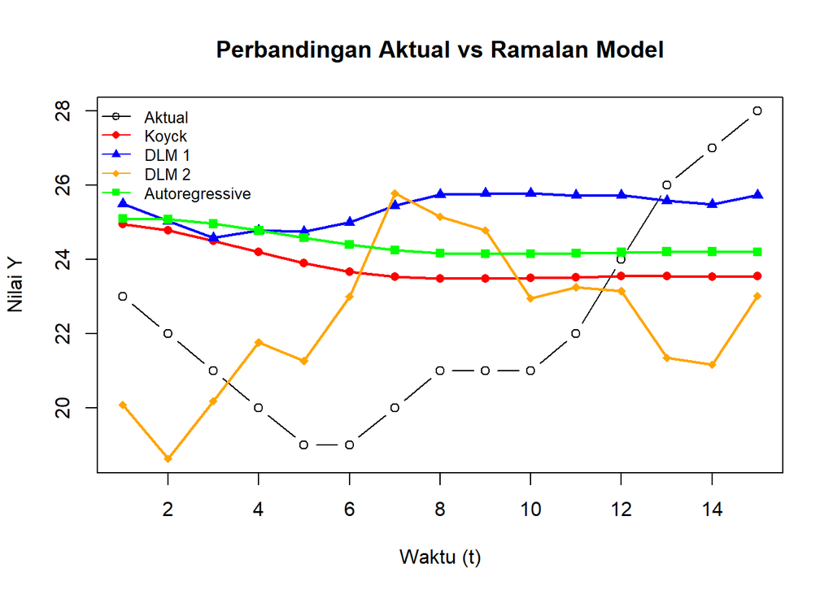

```r
# Atur layout grafik tunggal
par(mfrow = c(1, 1))

# Buat sumbu X sebagai indeks waktu
t <- 1:length(test$Y)

# Plot data aktual
plot(t, test$Y, type = "b", col = "black", ylim = range(c(test$Y,
                                                          fore.koyck$forecasts,
                                                          fore.dlm$forecasts,
                                                          fore.dlm2$forecasts,
                                                          fore.ardl$forecasts)),
     xlab = "Waktu (t)", ylab = "Nilai Y", main = "Perbandingan Aktual vs Ramalan Model")

# Tambahkan garis ramalan dari masing-masing model
lines(t, fore.koyck$forecasts, col = "red", lwd = 2)
points(t, fore.koyck$forecasts, col = "red", pch = 16)

lines(t, fore.dlm$forecasts, col = "blue", lwd = 2)
points(t, fore.dlm$forecasts, col = "blue", pch = 17)

lines(t, fore.dlm2$forecasts, col = "orange", lwd = 2)
points(t, fore.dlm2$forecasts, col = "orange", pch = 18)

lines(t, fore.ardl$forecasts, col = "green", lwd = 2)
points(t, fore.ardl$forecasts, col = "green", pch = 15)

# Tambahkan legenda
legend("topleft",
       legend = c("Aktual", "Koyck", "DLM 1", "DLM 2", "Autoregressive"),
       col = c("black", "red", "blue", "orange", "green"),
       lty = 1, pch = c(1, 16, 17, 18, 15),
       cex = 0.8, bty = "n")
```

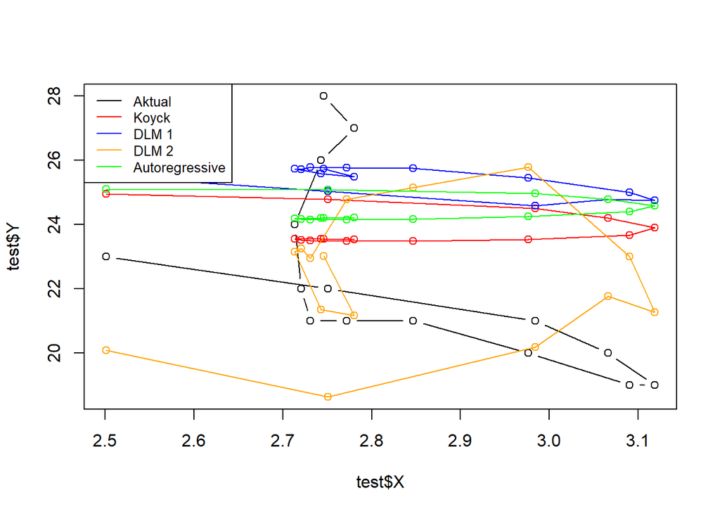

```r
par(mfrow=c(1,1))  # atur layout grafik tunggal

# plot data aktual
plot(test$X, test$Y, type="b", col="black", ylim = range(c(test$Y,
               fore.koyck$forecasts,
               fore.dlm$forecasts,
               fore.dlm2$forecasts,
               fore.ardl$forecasts))
)

# tambahkan garis ramalan dari masing-masing model
points(test$X, fore.koyck$forecasts, col="red");   lines(test$X, fore.koyck$forecasts, col="red")
points(test$X, fore.dlm$forecasts, col="blue");    lines(test$X, fore.dlm$forecasts, col="blue")
points(test$X, fore.dlm2$forecasts, col="orange"); lines(test$X, fore.dlm2$forecasts, col="orange")
points(test$X, fore.ardl$forecasts, col="green");  lines(test$X, fore.ardl$forecasts, col="green")

# legenda model
legend("topleft",
       c("Aktual", "Koyck","DLM 1","DLM 2", "Autoregressive"),
       lty=1, col=c("black","red","blue","orange","green"), cex=0.8)
```